# Summer Lab 2

Dylan Francisco

July 07, 2023

# Lab 2a: Exploratory Data Analysis

## Introduction

In this lab assignment, make sure you work in order of the code chunks, and **knit** after you complete each code chunk.

Consider the dataset `Wages1` from the `Ecdat` package.

```
##   exper    sex school     wage
## 1     9 female     13 6.315296
## 2    12 female     12 5.479770
## 3    11 female     11 3.642170
## 4     9 female     14 4.593337
## 5     8 female     14 2.418157
## 6     9 female     14 2.094058
```

This observational dataset records the years experienced, the years schooled, the sex, and the hourly wage for 3,294 workers in 1987. *A Guide to Modern Econometrics* by Marno Verbeek utilizes this data in a linear regression context. According to Marno Verbeek, this data is a subsample from the US National Longitudinal Study. The purpose of this tutorial is to practice the creative process in exploratory data analysis of asking questions and then investigating those questions using visuals and statistical summaries.

As a member of the birth class of 1988, I do not have any clue of what the workforce looked like in 1987. It is your job to apply your detective skills to the information hidden in this data. For future use, utilize the modified dataset`wage` according to the R code below:

```r
wage=as.tibble(Wages1) %>%
  rename(experience=exper) %>%
  arrange(school)
head(wage)
```

```
## # A tibble: 6 × 4
##   experience sex    school  wage
##        <int> <fct>   <int> <dbl>
## 1         18 male        3 5.52
## 2         15 male        4 3.56
## 3         18 male        4 9.10
## 4         10 female      5 0.603
## 5         11 male        5 3.80
## 6         14 male        5 7.50
```

## Part 1: Questions About Variation

### 1.1: Use a figure to find what is the most common number of years of experience found in the data (0.5 Points).

First, use `geom_bar()` to investigate the distribution of level of experience found in `wage`.

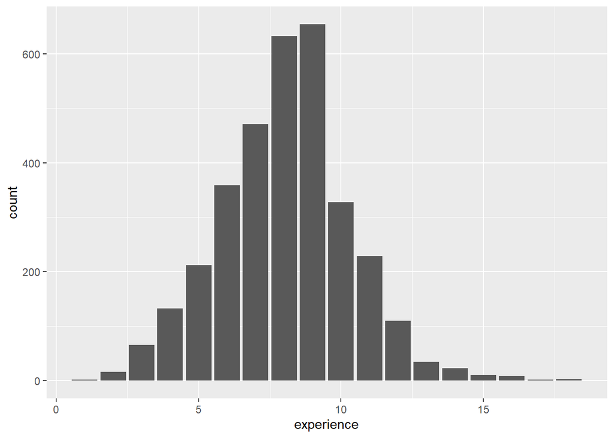

```r
ggplot(data = wage) +
  geom_bar(mapping = aes(x=experience))
```

### 1.2: Use a table to find what is the most common number of years of experience found in the data (1.5 Points).

Use `group_by(experience)` along with the pipe `%>%` to output the most common amount of years of experience along with the number of occurrences found in the data. The most common value for years of experience is 9 years and occurs 654 times. Fill in the blanks with the correct answers, and change `eval=True` to `eval=False` and print out the output that led you to your answer.

```r
wage %>%
  group_by(experience) %>%
  count() %>%
  arrange(desc(n)) %>%
  ungroup()
```

```
## # A tibble: 18 × 2
##    experience     n
##         <int> <int>
##  1          9   654
##  2          8   632
##  3          7   471
##  4          6   359
##  5         10   328
##  6         11   229
##  7          5   212
##  8          4   133
##  9         12   110
## 10          3    66
## 11         13    35
## 12         14    23
## 13          2    16
## 14         15    10
## 15         16     9
## 16         18     3
## 17          1     2
## 18         17     2
```

### 1.3: Use a figure to find what is the maximum number for years of schooling found in the data. (0.5 Points)

First, use `geom_bar()` to visualize the overall distribution of level of schooling found in the data.

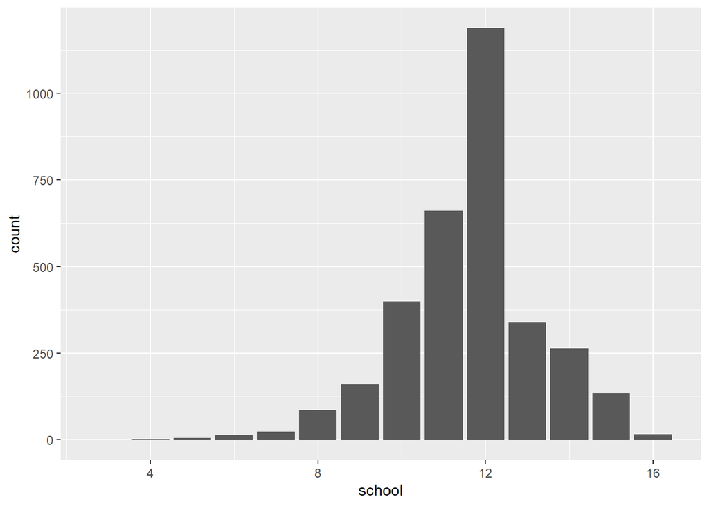

```r
ggplot( data = wage) +
  geom_bar(mapping = aes(x = school))
```

### 1.4: Use a table to find what is the maximum number for years of schooling found in the data. (1.5 Points)

Next, modify the code in Question 1.2 to display the maximum level of schooling and the number of workers in the data that had that number of schooling. The maximum number of years in school was 16 years which occurred 16 times in our sample. Fill in the blanks with the correct answers.

```r
wage %>%
  group_by(school) %>%
  count() %>%
  arrange(desc(school)) %>%
  ungroup()
```

```
## # A tibble: 14 × 2
##    school     n
##     <int> <int>
##  1     16    16
##  2     15   134
##  3     14   264
##  4     13   339
##  5     12  1188
##  6     11   661
##  7     10   399
##  8      9   161
##  9      8    86
## 10      7    24
## 11      6    14
## 12      5     5
## 13      4     2
## 14      3     1
```

## Part 2: Questions about Covariation

### 2.1: Follow-up to Questions 1-2: Is there a relationship between level of schooling and level of experience? (1 Point)

Use `geom_point()` to display a scatter plot representing the relationship between these two discrete numeric variables. Consider using `alpha=0.1` to indicate where the relationship is represented the best.

The years of experience seem to decrease (increase/decrease) as the years of schooling increases. Is this what you expected to see? no (yes/no).

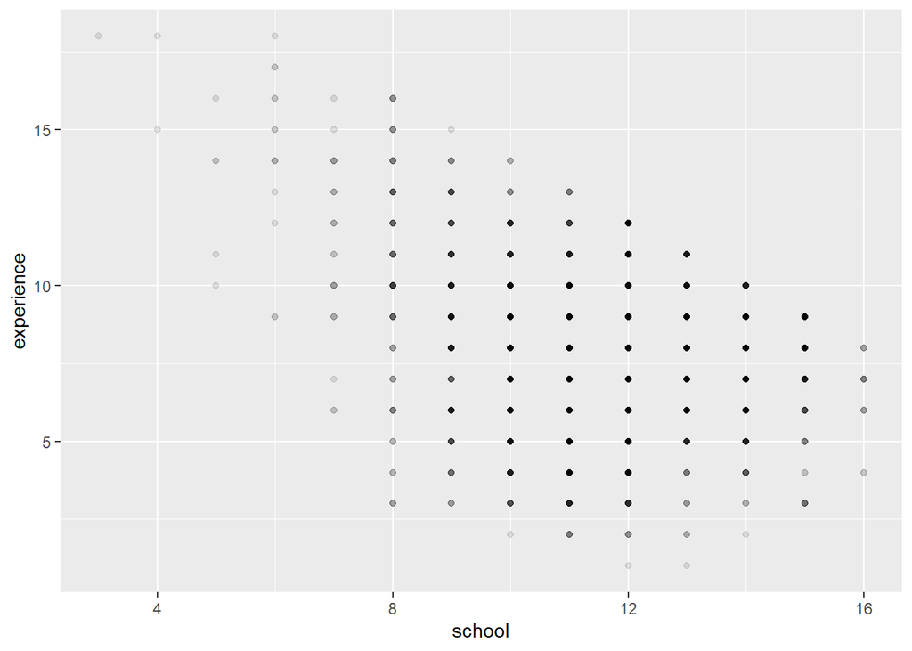

```r
ggplot(data = wage) +
  geom_point(mapping = aes(x = school, y = experience), alpha = 0.1)
```

Question: Practically, what reasons do you hypothesize for this observed relationship? Write your answer in complete sentences below:

At first, I thought that the more years of schooling, the more years of experience someone would have because they would be theoretically better at that job and continue to stay at that job for along time. However, it seems like with the lesser years of schooling, there are more people with more years experience than those with more years of schooling. I hypothesize this is because people who spent less time at school had more time to work at with their field, thus creating more years experience.

### 2.2: How do hourly wages differ between males and females? (1 Point)

Use `geom_freqpoly()` to compare the distribution of wage of females to the distribution of wage of males.

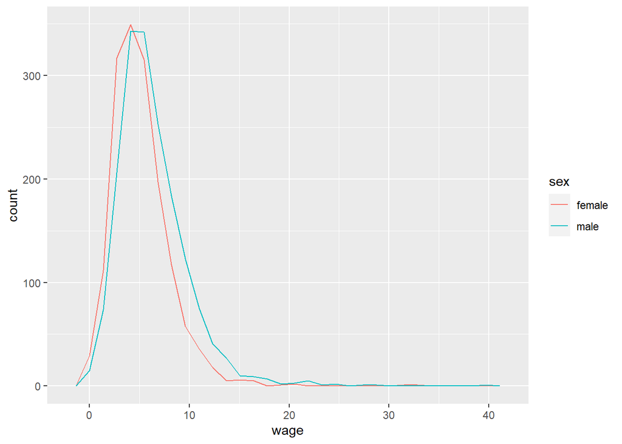

```r
ggplot(data = wage) +
  geom_freqpoly(mapping = aes(x = wage, color = sex))
```

Question: Where do these distributions look the same and/or where do they differ? Write your answer in complete sentences below:

These distributions look the same in terms of the overall shape. For example, they both peak around 350 in terms of the count and, between the wages of 0-15, have the shape of a negative parabola. However, these graphs differ in terms of the wage. The wages of females is consistently lagging behind the wages of the males. You can see that the peak of the female wage is less than the peak of the male wage and there are less females at the higher wages of 15 and above.

### 2.3: How do hourly wages differ between males and females? (1.5 Points)

Use `group_by()` along with summarize to report the mean `wage`, standard error of `wage`, and 95% confidence interval for the unknown population mean hourly wage for the various levels of `sex`. The standard error is equal to the standard deviation divided by the square root of the sample size. The 95% confidence interval is approximated by obtaining the lower and upper bound of an interval within 2 standard errors of the sample mean. Based on the confidence limits, do we have statistical evidence to say that the average hourly wage for men was different than the average hourly wage for women in 1987? yes (yes/no).

```r
wage %>%
  group_by(sex) %>%
  summarize(n=n(),mean= mean(wage),se= sd(wage)/sqrt(n()),
            lb=mean - (2 * se), ub=mean + (2 * se))
```

```
## # A tibble: 2 × 6
##   sex        n  mean     se    lb    ub
##   <fct>  <int> <dbl>  <dbl> <dbl> <dbl>
## 1 female  1569  5.15 0.0726  5.00  5.29
## 2 male    1725  6.31 0.0842  6.14  6.48
```

Question: How would you explain your answer in terms of the confidence intervals that are constructed below? Write your answer in complete sentences below:

In this example, using the 95% confidence intervals means that we are 95% confident that the mean of wages of males in 1987 was between 6.144536 and 6.481507. Similarly we are 95% confident that the mean of wages of females in 1987 was between 5.001698 and 5.292149. By using the mean and standard deviation we can come up with those confidence intervals to say that there is statistical evidence to say that the average hourly wage for mean was different than females.

### 2.4: Does the relationship between hourly wage and years of experience differ between the sexes? (0.5 Points)

Use `geom_point()` along with the option `color=sex` to overlay scatter plots. Does there seem to be a clear distinction between female and male regarding this relationship? yes (yes/no).

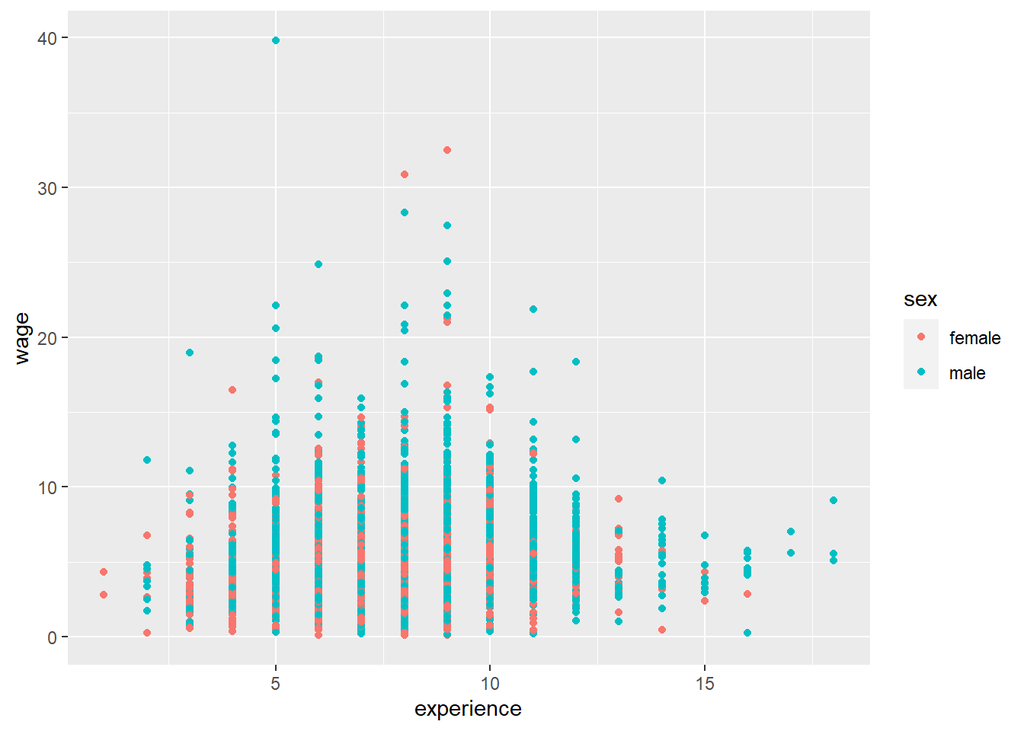

```r
ggplot(data = wage) +
  geom_point(mapping = aes(x = experience, y = wage, color = sex))
```

### 2.5: Does the relationship between hourly wage and years of schooling differ between the sexes? (0.5 Points)

Repeat the graphic created in Question 4 replacing `x=experience` with `x=school`. Does there seem to be a clear distinction between female and male regarding this relationship? yes (yes/no).

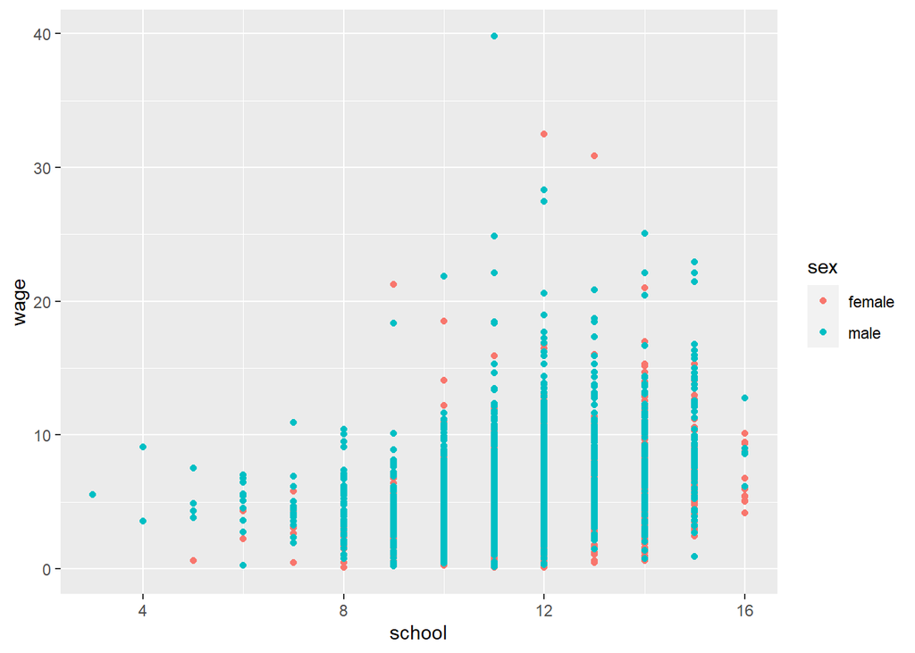

```r
ggplot(data = wage) +
  geom_point(mapping = aes(x = school, y = wage, color = sex))
```

### 2.6: What is the relationship between hourly wage and the interaction between the years of experience and years of schooling? (0.5 Points)

The graphic below summarizes the average hourly wage for the different combinations of schooling and experience level. The additional `facet_grid(~sex)` makes comparing the relationship of the three key numeric variables between the sexes quite easy.

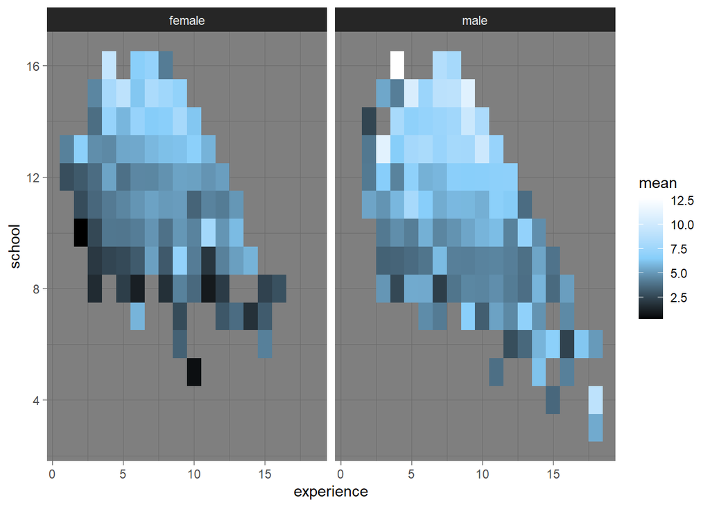

```r
wage %>%
  group_by(experience,school,sex) %>%
  summarize(n=n(),mean=mean(wage)) %>%
  ungroup() %>%
  ggplot() +
    geom_tile(aes(x=experience,y=school,fill=mean)) +
  scale_fill_gradientn(colors=c("black","lightskyblue","white"))+
    facet_grid(~sex) + theme_dark()
```

Question: What are some differences between the sexes regarding this relationship that are apparent in this chart? Write your answer in complete sentences below:

### 2.7: What is the relationship between hourly wage and the interaction between the years of experience and years of schooling? (1 Point)

The next figure is similar to the previous one except that the tile color reflects the standard deviation of wage rather than the mean. Interactions of experience and school levels containing less than or equal to 10 instances are ignored in this image.

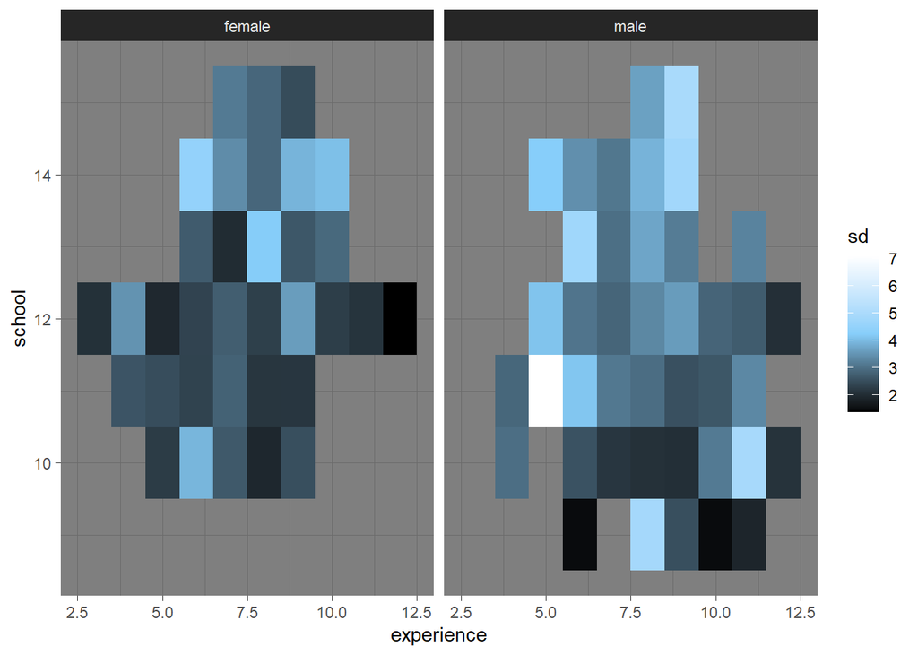

```r
wage %>%
  group_by(experience,school,sex) %>%
  summarize(n=n(),sd=sd(wage)) %>%
  ungroup() %>%
  filter(n>10) %>%
  ggplot() +
  geom_tile(aes(x=experience,y=school,fill=sd)) +
  scale_fill_gradientn(colors=c("black","lightskyblue","white"))+
  facet_grid(~sex) + theme_dark()
```

Question: Which plot is generally darker and what does that imply? Write your answer in complete sentences below:

The generally darker plot is the female chart. This implies that females who finished school and have between 2.5-12.5 years of experience tended to make similar wages, while the males had a higher variance of wage based on experience and school.

Question: Specifically for the scenario where a worker has 5 years of experience and 11 years of schooling, what does the extreme contrast between female and male cells imply for this figure? Write your answer in complete sentences below:

In this scenario, the implication is that a female worker with 5 years of experience and 11 years of schooling will tend to make an hourly wage similar to other.

# Lab 2b: Tidy Data

## Introduction

Baby Mario once had a dream to drop math knowledge on high school students. High schools are evaluated based on student achievement on standardized test scores. The self-proclaimed king, [Lebron James](http://lebronjames.com/), intends to donate $5 million to the district and funds will be distributed according to the improvement of these high schools in the area of mathematics. Because of the king’s proclamation, the bureaucratic district heads have pushed high schools to redirect all loose change to mathematics. Teachers of english, science, history, and other subjects have been pressured to dedicate portions of class time to math education. Teachers of music and the arts have been released because the king does not have time for that nonsense. The dreams of these children along with the king’s talents have been taken to Hollywood.

The [Cleveland school district](http://www.clevelandmetroschools.org/) is made up of 20 high schools uniquely identified by numbers 1 to 20. Within each high school, a random sample of 20 students are selected to participate in this study and are uniquely identified by numbers 1 to 20. All 400 students selected are assessed on their mathematics skills based on district designed standardized tests in the years 2017 and 2018. The scores and corresponding percentiles of these selected students for both years are simulated in the following R code.

```r
school.id=rep(1:20,each=20*2)
student.id=rep(rep(1:20,each=2),20)
type=rep(c("Score","Percentile"),20*20)
score2017=round(rnorm(20*20,mean=50,sd=10),0)
percentile2017=round(100*pnorm(score2017,mean=mean(score2017),sd=sd(score2017)),0)
score2018=round(rnorm(20*20,mean=75,sd=4),0)
percentile2018=round(100*pnorm(score2018,mean=mean(score2018),sd=sd(score2018)),0)
value2017=c(rbind(score2017,percentile2017))
value2018=c(rbind(score2018,percentile2018))

untidy.school = tibble(
                  school=school.id,
                  student=student.id,
                  type=type,
                  value2017=value2017,
                  value2018=value2018) %>%
                filter(!(school==1 & student==4)) %>% filter(!(school==12 & student==18)) %>%
                mutate(value2018=ifelse((school==1 & student==3)|(school==15 & student==18)|
                                          (school==5 & student==12),NA,value2018))
```

Below is an HTML table generated using the `xtable` package in R. For more information regarding this package, see the [xtable gallery](https://cran.r-project.org/web/packages/xtable/vignettes/xtableGallery.pdf). The R code in the code chunk converts an R data frame object to an HTML table. HTML table attributes can be specified within the function `print()`. The code chunk option `echo=F` prevents the code from showing and the option `results="asis"` ensures that the resulting HTML table is displayed when knitted to HTML. The table provides a preview of the first 10 rows of the simulated data. Knit the document to see the HTML table below.

| school | student | type | value2017 | value2018 |
| --- | --- | --- | --- | --- |
| 1 | 1 | Score | 58 | 82 |
| 1 | 1 | Percentile | 80 | 95 |
| 1 | 2 | Score | 56 | 72 |
| 1 | 2 | Percentile | 73 | 20 |
| 1 | 3 | Score | 51 |  |
| 1 | 3 | Percentile | 54 |  |
| 1 | 5 | Score | 49 | 70 |
| 1 | 5 | Percentile | 46 | 9 |
| 1 | 6 | Score | 46 | 74 |
| 1 | 6 | Percentile | 34 | 37 |

Along with the schools’ inability to appropriately drop math knowledge on these kids is their inability to record data in a format that is immediately usable. Using our understanding of the `tidyr` package, we can easily convert this table into a form that is useful for data analysis.

## Part 1: Creation of a Unique Student ID

The variable `school` uniquely identifies the school, but the variable `student` only uniquely identifies the student within the school. The problem is best illustrated by the `filter()` function in `dplyr`.

```r
untidy.school %>% filter(student==1) %>% head(4)
```

```
## # A tibble: 4 × 5
##   school student type       value2017 value2018
##    <int>   <int> <chr>          <dbl>     <dbl>
## 1      1       1 Score             58        82
## 2      1       1 Percentile        80        95
## 3      2       1 Score             62        71
## 4      2       1 Percentile        89        14
```

### 1.1: Create a unique identifier (1.5 Points)

The subsetted table contains scores and percentiles for two completely different children identified by `student==1`. We need to create a unique identifier for each student in the Cleveland school district. The `unite()` function can be utilized to create a new variable called `CID` by concatenating the identifiers for `school` and `student`. We want `CID` to follow the general form *SCHOOL.STUDENT*. For example, the `CID` for the first student in the table above would be “1.1”.

Create a new tibble called `untidy2.school` that fixes this problem without dropping the original variables `school` or `student`. Read the documentation for `unite()` either by searching on google or using `?unite` to prevent the loss of original variables in the creation of a new variable.

```r
untidy2.school = untidy.school %>%
                    unite(CID, school, student, sep = ".", remove = FALSE)

glimpse(untidy2.school) #Do Not Change Lines with the glimpse Function
```

```
## Rows: 796
## Columns: 6
## $ CID       <chr> "1.1", "1.1", "1.2", "1.2", "1.3", "1.3", "1.5", "1.5", "1.6…
## $ school    <int> 1, 1, 1, 1, 1, 1, 1, 1, 1, 1, 1, 1, 1, 1, 1, 1, 1, 1, 1, 1, …
## $ student   <int> 1, 1, 2, 2, 3, 3, 5, 5, 6, 6, 7, 7, 8, 8, 9, 9, 10, 10, 11, …
## $ type      <chr> "Score", "Percentile", "Score", "Percentile", "Score", "Perc…
## $ value2017 <dbl> 58, 80, 56, 73, 51, 54, 49, 46, 46, 34, 51, 54, 51, 54, 59, …
## $ value2018 <dbl> 82, 95, 72, 20, NA, NA, 70, 9, 74, 37, 80, 88, 80, 88, 79, 8…
```

## Part 2: Gather Variables With Yearly Values

### 2.1: Create a unique identifier (1.5 Points)

The variables `value2017` and `value2018` contain the scores and percentiles for two different years. In a new tibble called `untidy3.school`, based on `untidy2.school`, we want to create a new variable called `Year` and a new variable called `Value` that display the year and the result from that year, respectively. The variable `Year` should be a numeric vector containing either *2017* or *2018*. The most efficient way to modify the data in this manner is to start by renaming `value2017` and `value2018` to nonsynctactic names `2017` and `2018`. Remember that you need to surround nonsyncactic names with backticks to achieve this result.

```r
untidy3.school = untidy2.school %>%
                    rename(`2017`= value2017,`2018`= value2018) %>%
                    gather(`2017`:`2018`, key = "Year", value = "Value", convert=T)
glimpse(untidy3.school)
```

```
## Rows: 1,592
## Columns: 6
## $ CID     <chr> "1.1", "1.1", "1.2", "1.2", "1.3", "1.3", "1.5", "1.5", "1.6",…
## $ school  <int> 1, 1, 1, 1, 1, 1, 1, 1, 1, 1, 1, 1, 1, 1, 1, 1, 1, 1, 1, 1, 1,…
## $ student <int> 1, 1, 2, 2, 3, 3, 5, 5, 6, 6, 7, 7, 8, 8, 9, 9, 10, 10, 11, 11…
## $ type    <chr> "Score", "Percentile", "Score", "Percentile", "Score", "Percen…
## $ Year    <int> 2017, 2017, 2017, 2017, 2017, 2017, 2017, 2017, 2017, 2017, 20…
## $ Value   <dbl> 58, 80, 56, 73, 51, 54, 49, 46, 46, 34, 51, 54, 51, 54, 59, 82…
```

## Part 3: Spread Type of Value Into Multiple Columns

### 3.1: Create new variables using spread (1 point)

The variable `type` in `untidy3.school` indicates that two completely different variables are contained in the recently created variable called `Value`. Both the scores and percentiles of students are contained in `Value`. Using the function `spread()` we can create two new variables, `Score` and `Percentile`, that display the information contained in `Value` in separate columns. Using `untidy3.school`, create a new tibble called `tidy.school` that accomplishes these tasks.

```r
tidy.school = untidy3.school %>%
                    spread(key = "type", value = "Value")
glimpse(tidy.school)
```

```
## Rows: 796
## Columns: 6
## $ CID        <chr> "1.1", "1.1", "1.10", "1.10", "1.11", "1.11", "1.12", "1.12…
## $ school     <int> 1, 1, 1, 1, 1, 1, 1, 1, 1, 1, 1, 1, 1, 1, 1, 1, 1, 1, 1, 1,…
## $ student    <int> 1, 1, 10, 10, 11, 11, 12, 12, 13, 13, 14, 14, 15, 15, 16, 1…
## $ Year       <int> 2017, 2018, 2017, 2018, 2017, 2018, 2017, 2018, 2017, 2018,…
## $ Percentile <dbl> 80, 95, 50, 37, 11, 88, 23, 57, 87, 66, 76, 75, 46, 88, 62,…
## $ Score      <dbl> 58, 82, 50, 74, 38, 80, 43, 76, 61, 77, 57, 78, 49, 80, 53,…
```

## Part 4: Missing Data Analysis

The original data contains explicitly missing and implicitly missing values. Instances of both can be visibly seen in the first ten observations. Below is a table showing the first 10 observations in the cleaned dataset we called `tidy.school`. To appropriately, view this we have to sort our observations by `school` and `student` as seen in the original dataset `untidy.school`. Knit the document to see the HTML table below.

| CID | school | student | Year | Percentile | Score |
| --- | --- | --- | --- | --- | --- |
| 1.1 | 1 | 1 | 2017 | 80 | 58 |
| 1.1 | 1 | 1 | 2018 | 95 | 82 |
| 1.2 | 1 | 2 | 2017 | 73 | 56 |
| 1.2 | 1 | 2 | 2018 | 20 | 72 |
| 1.3 | 1 | 3 | 2017 | 54 | 51 |
| 1.3 | 1 | 3 | 2018 |  |  |
| 1.5 | 1 | 5 | 2017 | 46 | 49 |
| 1.5 | 1 | 5 | 2018 | 9 | 70 |
| 1.6 | 1 | 6 | 2017 | 34 | 46 |
| 1.6 | 1 | 6 | 2018 | 37 | 74 |

Based on the table above, you can see that student *3* from school *1* has a missing score and percentile for the year 2018. This is an example of explicitly missing information. In logitudinal studies where measures are taken on individuals over a fixed time period, this is a common occurrence. Hypothesize a reason for this scenario to happen.

Based on the table above, you can see that student *4* from school *1* is clearly missing scores and percentiles from both years *2017* and *2018*. This is an example of implicitly missing information. This is a less common occurrence, but try to hypothesize a reason for this scenario to happen.

### 4.1 Convert Implicitly Missing to Explicitly Missing (1 Point)

Use the `complete()` function to convert all implicitly missing to explicitly missing. Create a new table called `tidy2.school` that reports missing values as `NA` for all combinations of school, student, and year.

```r
tidy2.school=tidy.school %>%
  complete(school, student, Year)
```

The first 10 rows of `tidy2.school` are displayed below.

```r
tab.tidy2.school = tidy2.school %>%
  head(10) %>%
  xtable(digits=0,align="ccccccc")

print(tab.tidy2.school,type="html",include.rownames=F,
      html.table.attributes="align='center',
      rules='rows',
      width=50%,
      frame='hsides',
      border-spacing=5px"
)
```

| school | student | Year | CID | Percentile | Score |
| --- | --- | --- | --- | --- | --- |
| 1 | 1 | 2017 | 1.1 | 80 | 58 |
| 1 | 1 | 2018 | 1.1 | 95 | 82 |
| 1 | 2 | 2017 | 1.2 | 73 | 56 |
| 1 | 2 | 2018 | 1.2 | 20 | 72 |
| 1 | 3 | 2017 | 1.3 | 54 | 51 |
| 1 | 3 | 2018 | 1.3 |  |  |
| 1 | 4 | 2017 |  |  |  |
| 1 | 4 | 2018 |  |  |  |
| 1 | 5 | 2017 | 1.5 | 46 | 49 |
| 1 | 5 | 2018 | 1.5 | 9 | 70 |

### 4.2 Fixing the Data Using the Pipe (2 Points)

If you inspect the first 10 rows of `tidy2.school`, you should see that the variable `CID` is missing for student *4* from school *1* even though we know that this students unique district ID should be *“1.4”*. Using the pipe `%>%`, combine all previous statements in an order where this will not occur. Create a tibble named `final.tidy.school` using a chain of commands that begins with calling the original tibble `untidy.school`

```r
final.tidy.school = untidy.school %>%
                    rename(`2017`= value2017,`2018`= value2018) %>%
                    gather(`2017`:`2018`, key = "Year", value = "Value", convert=T) %>%
                    spread(key = "type", value = "Value") %>%
                    complete(school, student, Year) %>%
                    unite(CID, school, student, sep = ".", remove = FALSE)


glimpse(final.tidy.school)
```

```
## Rows: 800
## Columns: 6
## $ CID        <chr> "1.1", "1.1", "1.2", "1.2", "1.3", "1.3", "1.4", "1.4", "1.…
## $ school     <int> 1, 1, 1, 1, 1, 1, 1, 1, 1, 1, 1, 1, 1, 1, 1, 1, 1, 1, 1, 1,…
## $ student    <int> 1, 1, 2, 2, 3, 3, 4, 4, 5, 5, 6, 6, 7, 7, 8, 8, 9, 9, 10, 1…
## $ Year       <int> 2017, 2018, 2017, 2018, 2017, 2018, 2017, 2018, 2017, 2018,…
## $ Percentile <dbl> 80, 95, 73, 20, 54, NA, NA, NA, 46, 9, 34, 37, 54, 88, 54, …
## $ Score      <dbl> 58, 82, 56, 72, 51, NA, NA, NA, 49, 70, 46, 74, 51, 80, 51,…
```

## Part 5: Summarizing Figures

### 5.1: Follow-up question about money distribution (1 Point)

The figure below uses boxplots to show the distribution of scores in the 20 schools for the years 2017 and 2018.

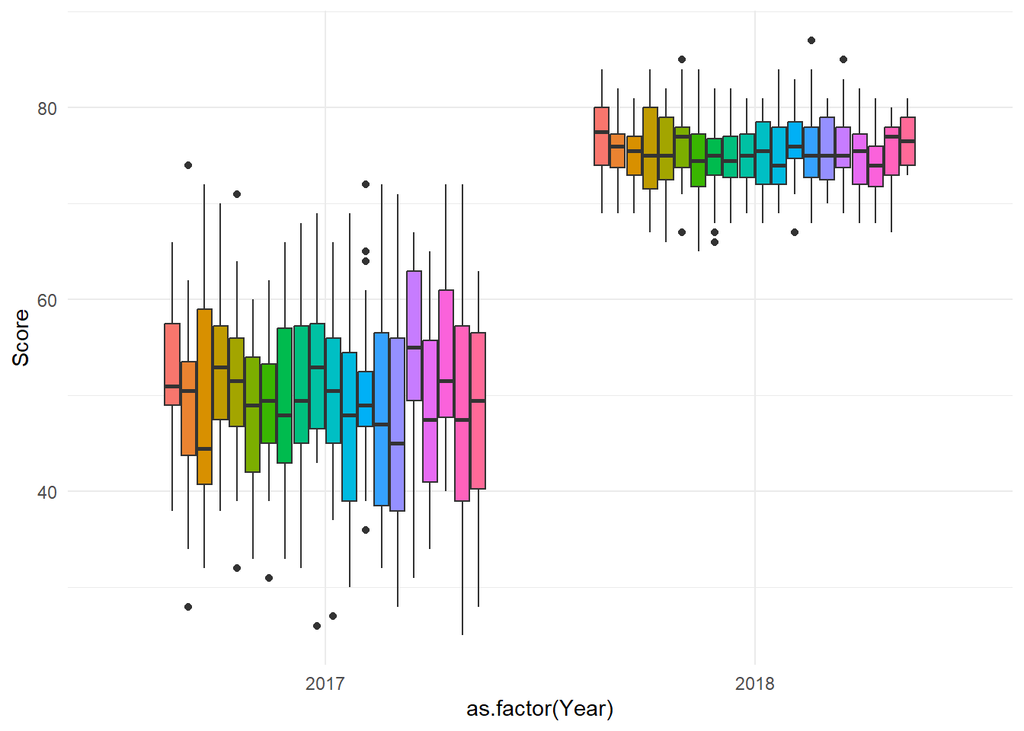

```r
ggplot(final.tidy.school) +
  geom_boxplot(aes(x=as.factor(Year),y=Score,fill=as.factor(school))) +
  guides(fill=F)+
  theme_minimal()
```

Question: If you were the district superintendent, how would you distribute the King’s ransom to these schools? In other words, how should Lebron James distribute the money to the schools. Write your answer in complete sentences below:

If I were the superintendent, I would want to award the money across all schools. Ideally, I would calculate to see which schools, on average, improved the most from 2017-2018. Those would be the primary choices to send more money to. However, I would like to have more data on the previous years of funding to those schools. If a certain school has consistently budget, it would make sense that test scores could improve the most in those schools. If that were the case, I may want to provide more funding to schools that do not normally receive as much funding.

### 5.2: Follow-up question about inspecting the improvement (2 Points)

Using different colors for each student, the next two pictures show the change in test scores and percentiles for all students (without missing values) sampled from the district. Both of these pictures are necessary in understanding the improvement in mathematical knowledge on the student level. As you can see, they are very different from each other. Hypothesize an educational strategy the district might have taken that would have caused this phenomenon to occur.

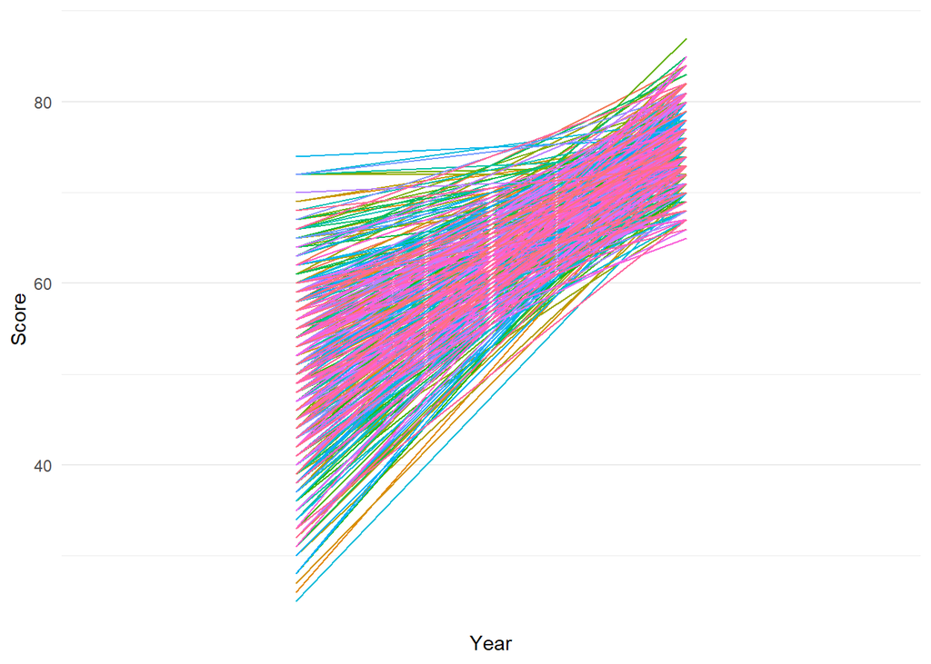

```r
ggplot(final.tidy.school) +
  geom_line(aes(x=Year,y=Score,color=as.factor(CID))) +
  guides(color=F) +
  scale_x_discrete(breaks=c(2017,2018),labels=c(2017,2018)) +
  theme_minimal()
```

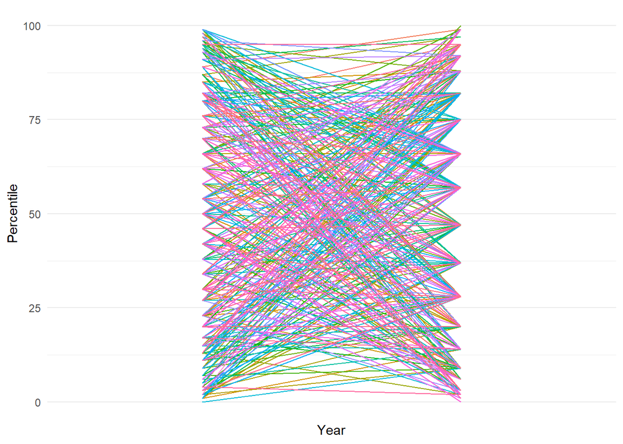

```r
ggplot(final.tidy.school) +
  geom_line(aes(x=Year,y=Percentile,color=as.factor(CID))) +
  guides(color=F) +
  scale_x_discrete(breaks=c(2017,2018),labels=c(2017,2018)) +
  theme_minimal()
```

Question: Do you believe the students actually improved in their math knowledge? Why or why not? The schools knew that they were going to get money based off the improvement of the math scores. What do we learn about the grades of the students when compared to each other. Think about this and write your answer in a well-written paragraph below:

In my opinion, I think there is basis to say that the students did improve their math knowledge. When looking at the graph of the scores from 2017-2018, it is clear that almost all students improved on their scores from the year before. The percentile graph can be explained as students who had no to moderate improvement in test scores received a large difference in percentile drop because there were so many other students who improved on the second test, skewing the data for the percentiles up. Even though the student’s had to spend less time in other subjects and most likely lost out on knowledge there, it does seem to have improved their math knowledge.